# Tarea 9

Shantal Chavarría

2020-10-13

# Pregunta 1

[30 puntos] En esta pregunta utiliza los datos (tumores.csv). Se trata de un conjunto de datos de características del tumor cerebral que incluye cinco variables de primer orden y ocho de textura y cuatro parámetros de evaluación de la calidad con el nivel objetivo. La variables son: Media, Varianza, Desviación estándar, Asimetría, Kurtosis, Contraste, Energía, ASM (segundo momento angular), Entropía, Homogeneidad, Disimilitud, Correlación, Grosor, PSNR (Pico de la relación señal-ruido), SSIM (Indice de Similitud Estructurada), MSE (Mean Square Error), DC (Coeficiente de Dados) y la variable a predecir tipo (1 = Tumor, 0 = No-Tumor). Realice lo siguiente: ## 1. Cargue la tabla de datos tumores.csv en R y genere en R usando la función createDataPartition(…) del paquete caret la tabla de testing con una 25 % de los datos y con el resto de los datos genere una tabla de aprendizaje.

```r
library(readr)
library(caret)
library(traineR)
library(rpart)
library(rpart.plot)


tumores <- read.table("Datos Tarea/tumores.csv", sep = ",", dec = ".", header = TRUE)[,-1]

tumores$tipo <- as.factor(ifelse(tumores$tipo ==1, "SI", "NO"))

p <- createDataPartition(tumores$tipo, p = 0.25, list = FALSE)

ttesting <- tumores[p,]
taprendizaje <- tumores[-p,]
```

## 2.

Usando árboles de Decisión (con traineR) genere un modelo predictivo para la tabla de aprendizaje. Modifique los parámetros del árbol de decisión para lograr los mejores resultados posibles. Grafique el árbol obtenido.

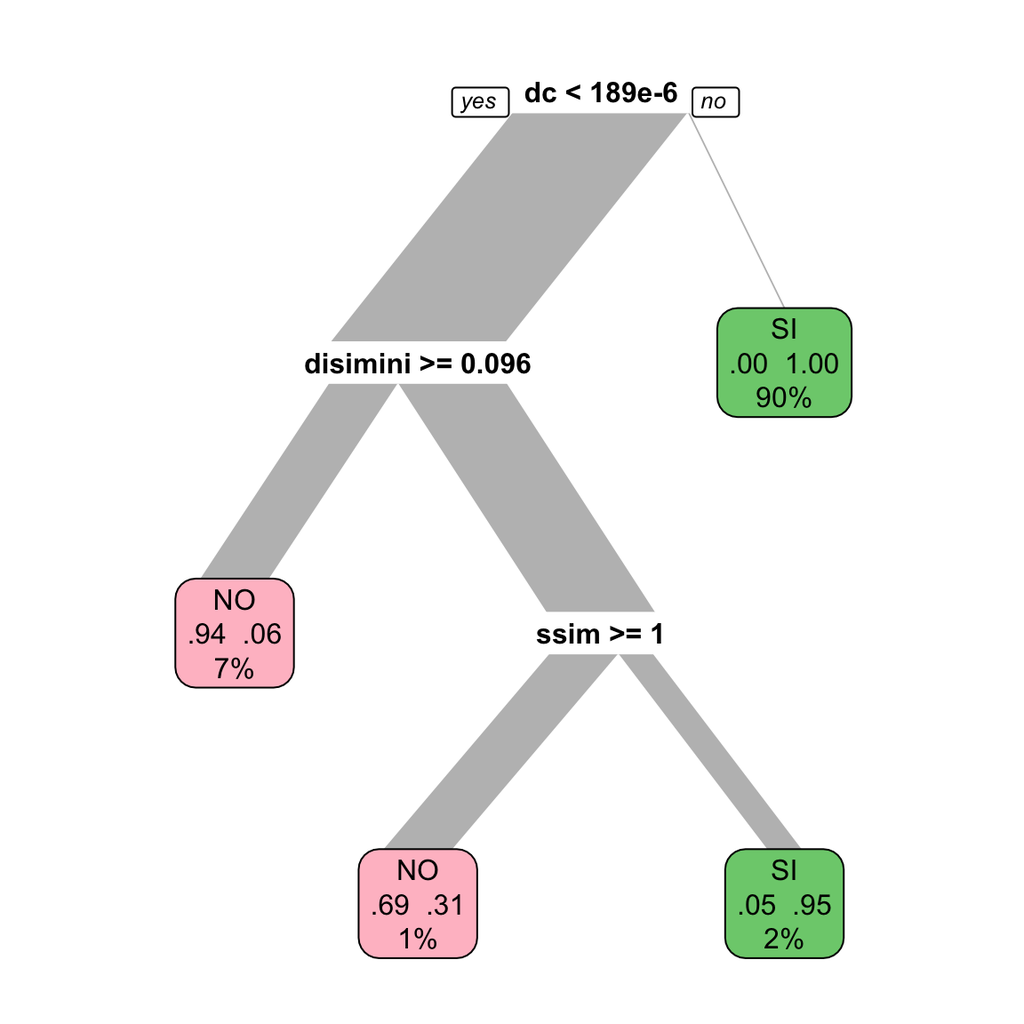

```r
modelo <- train.rpart(tipo~.,taprendizaje, minsplit=20, maxdepth = 4)

prediccion <- predict(modelo, ttesting, type = "class")

prp(modelo,extra=104,branch.type=2, box.col=c("pink", "palegreen3","cyan")[modelo$frame$yval])
```

## 3.

Construya una tabla para los índices anteriores que permita comparar el resultado de los árboles de Decisión con respecto a los métodos generados en las tareas anteriores ¿Cúal método es mejor?

### Árboles de Decisión

```r
indices.general <- function(MC) {
  precision.global <- sum(diag(MC))/sum(MC)
  error.global <- 1 - precision.global
  precision.categoria <- diag(MC)/rowSums(MC)
  falsos.positivos<- MC[1,2]/rowSums(MC)[1]
  falsos.negativos<- MC[2,1]/rowSums(MC)[2]
  asertividad.positiva<-MC[2,2]/ colSums(MC)[2]
  asertividas.negativa<-MC[1,1]/ colSums(MC)[1]

  res <- list(precision.global = precision.global, error.global = error.global,
              precision.categoria = precision.categoria, falsos.positivos= falsos.positivos, falsos.negativos=falsos.negativos,
              asertividad.positiva=asertividad.positiva,asertividas.negativa=asertividas.negativa)
  names(res) <- c("Precisión Global", "Error Global",
                  "Precisión por categoría","Falsos positivos","Falsos negativos","Asertividad Positiva", "Asertvidad Negativa")
  return(res)
}

MC.AD <-  confusion.matrix(newdata = ttesting, prediccion)
```

### KNN

```r
#rectangular
modelo.rectangular <-train.knn(tipo~.,data=taprendizaje, kernel = "rectangular")
prediccion.rectangular <- predict(modelo.rectangular, ttesting, type = "class")

MC.rectangular <- confusion.matrix(ttesting, prediccion.rectangular)

#triangular
modelo.triangular <- train.knn(tipo~., data = taprendizaje, kernel = "triangular")

prediccion.triangular <- predict(modelo.triangular, ttesting, type = "class")

MC.triangular<- confusion.matrix(ttesting ,prediccion.triangular)

#epanechnikov
modelo.epanechnikov <- train.knn(tipo~., data = taprendizaje, kernel = "epanechnikov")

prediccion.epanechnikov <- predict(modelo.epanechnikov, ttesting, type = "class")

MC.epanechnikov<- confusion.matrix(ttesting ,prediccion.epanechnikov)

#biweight
modelo.biweight <- train.knn(tipo~., data = taprendizaje, kernel = "biweight")

prediccion.biweight <- predict(modelo.biweight, ttesting, type = "class")

MC.biweight<- confusion.matrix(ttesting ,prediccion.biweight)

#triweight
modelo.triweight <- train.knn(tipo~., data = taprendizaje, kernel = "triweight")

prediccion.triweight <- predict(modelo.triweight, ttesting, type = "class")

MC.triweight<- confusion.matrix(ttesting ,prediccion.triweight)

#cos
modelo.cos <- train.knn(tipo~., data = taprendizaje, kernel = "cos")

prediccion.cos <- predict(modelo.cos, ttesting, type = "class")

MC.cos<- confusion.matrix(ttesting,prediccion.cos)

#inv
modelo.inv <- train.knn(tipo~., data = taprendizaje, kernel = "inv")

prediccion.inv <- predict(modelo.inv, ttesting, type = "class")

MC.inv<- confusion.matrix(ttesting ,prediccion.inv)

#optimal
modelo.optimal <- train.knn(tipo~., data = taprendizaje, kernel = "optimal")

prediccion.optimal <- predict(modelo.optimal, ttesting, type = "class")

MC.optimal<- confusion.matrix(ttesting ,prediccion.optimal)
```

### SVM

```r
#linear
modelo.linear <- train.svm(tipo~., data = taprendizaje, kernel = "linear")
prediccion.linear <- predict(modelo.linear, ttesting , type = "class")
MC.Linear <- confusion.matrix(ttesting, prediccion.linear)

#polynomial
modelo.polynomial <- train.svm(tipo~., data = taprendizaje, kernel = "polynomial")
prediccion.polynomial <- predict(modelo.polynomial, ttesting , type = "class")
MC.polynomial <- confusion.matrix(ttesting, prediccion.polynomial)

#radial
modelo.radial <- train.svm(tipo~., data = taprendizaje, kernel = "radial")
prediccion.radial <- predict(modelo.radial, ttesting , type = "class")
MC.radial <- confusion.matrix(ttesting, prediccion.radial)

#sigmoid
modelo.sigmoid <- train.svm(tipo~., data = taprendizaje, kernel = "sigmoid")
prediccion.sigmoid <- predict(modelo.sigmoid, ttesting , type = "class")
MC.sigmoid <- confusion.matrix(ttesting, prediccion.sigmoid)
```

### Tabla Comparativa

```r
library(dplyr)


indices1 <- indices.general(MC.AD)
indices2 <- indices.general(MC.rectangular)
indices3 <- indices.general(MC.triangular)
indices4 <- indices.general(MC.epanechnikov)
indices5 <- indices.general(MC.biweight)
indices6 <- indices.general(MC.triweight)
indices7 <- indices.general(MC.cos)
indices8 <- indices.general(MC.inv)

indices9 <- indices.general(MC.Linear)
indices10 <- indices.general(MC.polynomial)
indices11 <- indices.general(MC.radial)
indices12 <- indices.general(MC.sigmoid)



indices1$`Precisión por categoría`<-sprintf("%f,%f", indices1$`Precisión por categoría`[1], indices1$`Precisión por categoría`[2])

indices2$`Precisión por categoría`<-sprintf("%f,%f", indices2$`Precisión por categoría`[1], indices2$`Precisión por categoría`[2])

indices3$`Precisión por categoría`<-sprintf("%f,%f", indices3$`Precisión por categoría`[1], indices3$`Precisión por categoría`[2])

indices4$`Precisión por categoría`<-sprintf("%f,%f", indices4$`Precisión por categoría`[1], indices4$`Precisión por categoría`[2])

indices5$`Precisión por categoría`<-sprintf("%f,%f", indices5$`Precisión por categoría`[1], indices5$`Precisión por categoría`[2])

indices6$`Precisión por categoría`<-sprintf("%f,%f", indices6$`Precisión por categoría`[1], indices6$`Precisión por categoría`[2])

indices7$`Precisión por categoría`<-sprintf("%f,%f", indices7$`Precisión por categoría`[1], indices7$`Precisión por categoría`[2])

indices8$`Precisión por categoría`<-sprintf("%f,%f", indices8$`Precisión por categoría`[1], indices8$`Precisión por categoría`[2])

indices9$`Precisión por categoría`<-sprintf("%f,%f", indices9$`Precisión por categoría`[1], indices9$`Precisión por categoría`[2])

indices10$`Precisión por categoría`<-sprintf("%f,%f", indices10$`Precisión por categoría`[1], indices10$`Precisión por categoría`[2])

indices11$`Precisión por categoría`<-sprintf("%f,%f", indices11$`Precisión por categoría`[1], indices11$`Precisión por categoría`[2])

indices12$`Precisión por categoría`<-sprintf("%f,%f", indices12$`Precisión por categoría`[1], indices12$`Precisión por categoría`[2])


tablaComparativa <-  rbind(as.data.frame(indices1),as.data.frame(indices2),as.data.frame(indices3),as.data.frame(indices4),as.data.frame(indices5),as.data.frame(indices6),as.data.frame(indices7),as.data.frame(indices8),as.data.frame(indices9),as.data.frame(indices10),as.data.frame(indices11),as.data.frame(indices12))

rownames(tablaComparativa) <- c("arboles decision","rectangular", "triangular", "epanechnikov", "biweight", "triweight", "cos", "inv","linear","polynomial","radial", "sigmoid")

tablaComparativa
```

```
                 Precisión.Global Error.Global Precisión.por.categoría
arboles decision         0.984375     0.015625       0.920000,0.989831
rectangular              0.950000     0.050000       0.480000,0.989831
triangular               0.953125     0.046875       0.560000,0.986441
epanechnikov             0.946875     0.053125       0.480000,0.986441
biweight                 0.946875     0.053125       0.480000,0.986441
triweight                0.953125     0.046875       0.560000,0.986441
cos                      0.946875     0.053125       0.440000,0.989831
inv                      0.956250     0.043750       0.560000,0.989831
linear                   0.978125     0.021875       0.840000,0.989831
polynomial               0.943750     0.056250       0.280000,1.000000
                 Falsos.positivos Falsos.negativos Asertividad.Positiva
arboles decision             0.08       0.01016949            0.9931973
rectangular                  0.52       0.01016949            0.9573770
triangular                   0.44       0.01355932            0.9635762
epanechnikov                 0.52       0.01355932            0.9572368
biweight                     0.52       0.01355932            0.9572368
triweight                    0.44       0.01355932            0.9635762
cos                          0.56       0.01016949            0.9542484
inv                          0.44       0.01016949            0.9636964
linear                       0.16       0.01016949            0.9864865
polynomial                   0.72       0.00000000            0.9424920
                 Asertvidad.Negativa
arboles decision           0.8846154
rectangular                0.8000000
triangular                 0.7777778
epanechnikov               0.7500000
biweight                   0.7500000
triweight                  0.7777778
cos                        0.7857143
inv                        0.8235294
linear                     0.8750000
polynomial                 1.0000000
 [ reached 'max' / getOption("max.print") -- omitted 2 rows ]
```

```r
#Mejor Método basados en su Precisión Global
tablaComparativa%>%
  filter(Precisión.Global ==  max(Precisión.Global))
```

```
                 Precisión.Global Error.Global Precisión.por.categoría
arboles decision         0.984375     0.015625       0.920000,0.989831
                 Falsos.positivos Falsos.negativos Asertividad.Positiva
arboles decision             0.08       0.01016949            0.9931973
                 Asertvidad.Negativa
arboles decision           0.8846154
```

Seleccionando el método con mayor Precisión Global Arboles de Decisión sería el de mejor resultados.

# Pregunta 2

[30 puntos] Esta pregunta utiliza los datos sobre la conocida historia y tragedia del Titanic, usando los datos titanicV2020.csv de los pasajeros se trata de predecir la supervivencia o no de un pasajero. Realice lo siguiente:

## 1.

Cargue la tabla de datos titanicV2020.csv, asegúrese de recodificar las variables cualitativas y de ignorar variables que no se deben usar.

```r
titanic <- read.table("Datos Tarea/titanicV2020.csv", sep = ",", dec = ".", header = TRUE, stringsAsFactors = TRUE)

titanic <- titanic[,-c(1,4,9,11)]

titanic <- na.omit(titanic)

titanic$Survived <- as.factor(ifelse(titanic$Survived == 1, "SI", "NO"))
```

## 2.

Usando el comando sample de R genere al azar una tabla aprendizaje con un 80 % de los datos y con el resto de los datos genere una tabla de aprendizaje.

```r
n <- dim(titanic)[1]

muestra <- sample(1:n,floor(0.80*n))

ttesting <- titanic[-muestra,]
taprendizaje <- titanic[muestra,]
```

## 3.

Usando árboles de Decisión (con traineR) genere un modelo predictivo para la tabla de aprendizaje. Modifique los parámetros del árbol de decisión para lograr los mejores resultados posibles. Grafique el árbol obtenido.

```r
modelo <- train.rpart(Survived~., data = taprendizaje,minsplit=20, maxdepth = 4)

prediccion <- predict(modelo,ttesting,type = "class")
MC.AD <- confusion.matrix(ttesting,prediccion)

indices.general(MC.AD)
```

```
$`Precisión Global`
[1] 0.8660287

$`Error Global`
[1] 0.1339713

$`Precisión por categoría`
       NO        SI
0.9191176 0.7671233

$`Falsos positivos`
        NO
0.08088235

$`Falsos negativos`
       SI
0.2328767

$`Asertividad Positiva`
       SI
0.8358209

$`Asertvidad Negativa`
       NO
0.8802817
```

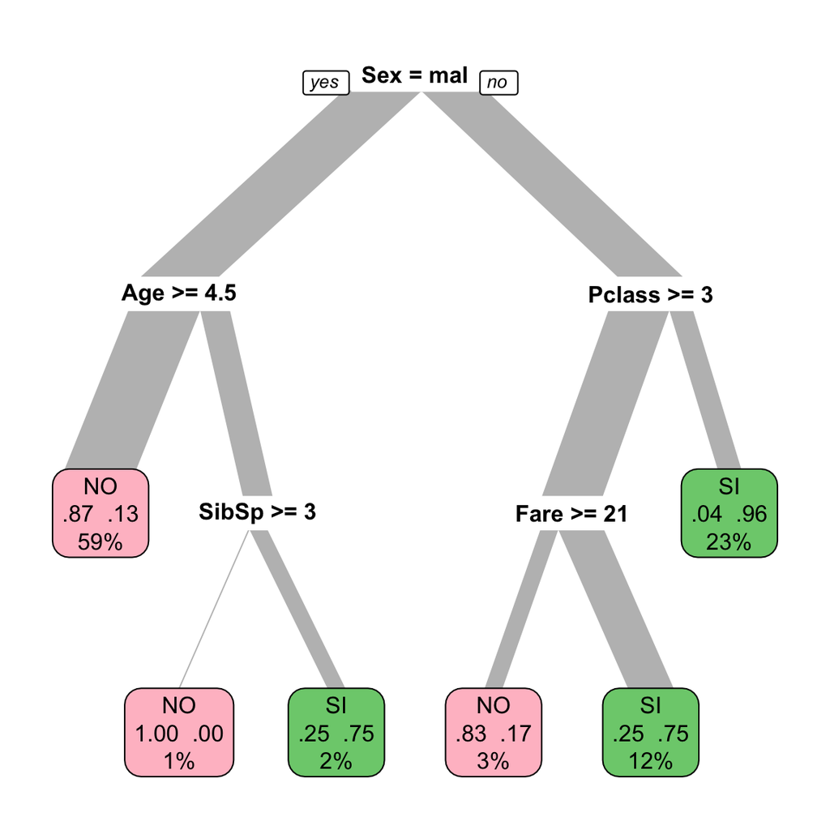

```r
prp(modelo,
    extra=104,
    branch.type=2,
    box.col=c("pink",
              "palegreen3",
              "cyan")[modelo$frame$yval])
```

## 4.

Construya una tabla para los índices anteriores que permita comparar el resultado de los árboles de Decisión con respecto a los métodos generados en las tareas anteriores ¿Cúal método es mejor?

### KNN

```r
#rectangular
modelo.rectangular <-train.knn(Survived~.,data=taprendizaje, kernel = "rectangular")
prediccion.rectangular <- predict(modelo.rectangular, ttesting, type = "class")

MC.rectangular <- confusion.matrix(ttesting, prediccion.rectangular)

#triangular
modelo.triangular <- train.knn(Survived~., data = taprendizaje, kernel = "triangular")

prediccion.triangular <- predict(modelo.triangular, ttesting, type = "class")

MC.triangular<- confusion.matrix(ttesting ,prediccion.triangular)

#epanechnikov
modelo.epanechnikov <- train.knn(Survived~., data = taprendizaje, kernel = "epanechnikov")

prediccion.epanechnikov <- predict(modelo.epanechnikov, ttesting, type = "class")

MC.epanechnikov<- confusion.matrix(ttesting ,prediccion.epanechnikov)

#biweight
modelo.biweight <- train.knn(Survived~., data = taprendizaje, kernel = "biweight")

prediccion.biweight <- predict(modelo.biweight, ttesting, type = "class")

MC.biweight<- confusion.matrix(ttesting ,prediccion.biweight)

#triweight
modelo.triweight <- train.knn(Survived~., data = taprendizaje, kernel = "triweight")

prediccion.triweight <- predict(modelo.triweight, ttesting, type = "class")

MC.triweight<- confusion.matrix(ttesting ,prediccion.triweight)

#cos
modelo.cos <- train.knn(Survived~., data = taprendizaje, kernel = "cos")

prediccion.cos <- predict(modelo.cos, ttesting, type = "class")

MC.cos<- confusion.matrix(ttesting,prediccion.cos)

#inv
modelo.inv <- train.knn(Survived~., data = taprendizaje, kernel = "inv")

prediccion.inv <- predict(modelo.inv, ttesting, type = "class")

MC.inv<- confusion.matrix(ttesting ,prediccion.inv)

#optimal
modelo.optimal <- train.knn(Survived~., data = taprendizaje, kernel = "optimal")

prediccion.optimal <- predict(modelo.optimal, ttesting, type = "class")

MC.optimal<- confusion.matrix(ttesting ,prediccion.optimal)
```

### SVM

```r
#linear
modelo.linear <- train.svm(Survived~., data = taprendizaje, kernel = "linear")
prediccion.linear <- predict(modelo.linear, ttesting , type = "class")
MC.Linear <- confusion.matrix(ttesting, prediccion.linear)

#polynomial
modelo.polynomial <- train.svm(Survived~., data = taprendizaje, kernel = "polynomial")
prediccion.polynomial <- predict(modelo.polynomial, ttesting , type = "class")
MC.polynomial <- confusion.matrix(ttesting, prediccion.polynomial)

#radial
modelo.radial <- train.svm(Survived~., data = taprendizaje, kernel = "radial")
prediccion.radial <- predict(modelo.radial, ttesting , type = "class")
MC.radial <- confusion.matrix(ttesting, prediccion.radial)

#sigmoid
modelo.sigmoid <- train.svm(Survived~., data = taprendizaje, kernel = "sigmoid")
prediccion.sigmoid <- predict(modelo.sigmoid, ttesting , type = "class")
MC.sigmoid <- confusion.matrix(ttesting, prediccion.sigmoid)
```

### Tabla Comparativa

```r
library(dplyr)


indices1 <- indices.general(MC.AD)
indices2 <- indices.general(MC.rectangular)
indices3 <- indices.general(MC.triangular)
indices4 <- indices.general(MC.epanechnikov)
indices5 <- indices.general(MC.biweight)
indices6 <- indices.general(MC.triweight)
indices7 <- indices.general(MC.cos)
indices8 <- indices.general(MC.inv)

indices9 <- indices.general(MC.Linear)
indices10 <- indices.general(MC.polynomial)
indices11 <- indices.general(MC.radial)
indices12 <- indices.general(MC.sigmoid)



indices1$`Precisión por categoría`<-sprintf("%f,%f", indices1$`Precisión por categoría`[1], indices1$`Precisión por categoría`[2])

indices2$`Precisión por categoría`<-sprintf("%f,%f", indices2$`Precisión por categoría`[1], indices2$`Precisión por categoría`[2])

indices3$`Precisión por categoría`<-sprintf("%f,%f", indices3$`Precisión por categoría`[1], indices3$`Precisión por categoría`[2])

indices4$`Precisión por categoría`<-sprintf("%f,%f", indices4$`Precisión por categoría`[1], indices4$`Precisión por categoría`[2])

indices5$`Precisión por categoría`<-sprintf("%f,%f", indices5$`Precisión por categoría`[1], indices5$`Precisión por categoría`[2])

indices6$`Precisión por categoría`<-sprintf("%f,%f", indices6$`Precisión por categoría`[1], indices6$`Precisión por categoría`[2])

indices7$`Precisión por categoría`<-sprintf("%f,%f", indices7$`Precisión por categoría`[1], indices7$`Precisión por categoría`[2])

indices8$`Precisión por categoría`<-sprintf("%f,%f", indices8$`Precisión por categoría`[1], indices8$`Precisión por categoría`[2])

indices9$`Precisión por categoría`<-sprintf("%f,%f", indices9$`Precisión por categoría`[1], indices9$`Precisión por categoría`[2])

indices10$`Precisión por categoría`<-sprintf("%f,%f", indices10$`Precisión por categoría`[1], indices10$`Precisión por categoría`[2])

indices11$`Precisión por categoría`<-sprintf("%f,%f", indices11$`Precisión por categoría`[1], indices11$`Precisión por categoría`[2])

indices12$`Precisión por categoría`<-sprintf("%f,%f", indices12$`Precisión por categoría`[1], indices12$`Precisión por categoría`[2])


tablaComparativa <-  rbind(as.data.frame(indices1),as.data.frame(indices2),as.data.frame(indices3),as.data.frame(indices4),as.data.frame(indices5),as.data.frame(indices6),as.data.frame(indices7),as.data.frame(indices8),as.data.frame(indices9),as.data.frame(indices10),as.data.frame(indices11),as.data.frame(indices12))

rownames(tablaComparativa) <- c("arboles decision","rectangular", "triangular", "epanechnikov", "biweight", "triweight", "cos", "inv","linear","polynomial","radial", "sigmoid")

tablaComparativa
```

```
                 Precisión.Global Error.Global Precisión.por.categoría
arboles decision        0.8660287    0.1339713       0.919118,0.767123
rectangular             0.8133971    0.1866029       0.867647,0.712329
triangular              0.8325359    0.1674641       0.897059,0.712329
epanechnikov            0.8325359    0.1674641       0.897059,0.712329
biweight                0.8325359    0.1674641       0.889706,0.726027
triweight               0.8421053    0.1578947       0.897059,0.739726
cos                     0.8277512    0.1722488       0.897059,0.698630
inv                     0.8133971    0.1866029       0.860294,0.726027
linear                  0.8660287    0.1339713       0.919118,0.767123
polynomial              0.8516746    0.1483254       0.919118,0.726027
                 Falsos.positivos Falsos.negativos Asertividad.Positiva
arboles decision       0.08088235        0.2328767            0.8358209
rectangular            0.13235294        0.2876712            0.7428571
triangular             0.10294118        0.2876712            0.7878788
epanechnikov           0.10294118        0.2876712            0.7878788
biweight               0.11029412        0.2739726            0.7794118
triweight              0.10294118        0.2602740            0.7941176
cos                    0.10294118        0.3013699            0.7846154
inv                    0.13970588        0.2739726            0.7361111
linear                 0.08088235        0.2328767            0.8358209
polynomial             0.08088235        0.2739726            0.8281250
                 Asertvidad.Negativa
arboles decision           0.8802817
rectangular                0.8489209
triangular                 0.8531469
epanechnikov               0.8531469
biweight                   0.8581560
triweight                  0.8652482
cos                        0.8472222
inv                        0.8540146
linear                     0.8802817
polynomial                 0.8620690
 [ reached 'max' / getOption("max.print") -- omitted 2 rows ]
```

```r
#Mejor Método basado en su Precisión Global
tablaComparativa%>%
  filter(Precisión.Global ==  max(Precisión.Global))
```

```
                 Precisión.Global Error.Global Precisión.por.categoría
arboles decision        0.8660287    0.1339713       0.919118,0.767123
linear                  0.8660287    0.1339713       0.919118,0.767123
                 Falsos.positivos Falsos.negativos Asertividad.Positiva
arboles decision       0.08088235        0.2328767            0.8358209
linear                 0.08088235        0.2328767            0.8358209
                 Asertvidad.Negativa
arboles decision           0.8802817
linear                     0.8802817
```

# Pregunta 3

[30 puntos] En este ejercicio vamos a predecir números escritos a mano (Hand Written Digit Recognition), la tabla de de datos está en el archivo ZipData 2020.csv. En la figura siguiente se ilustran los datos:

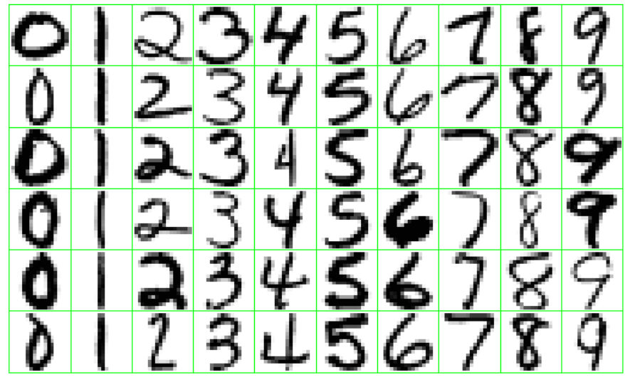

```r
knitr::include_graphics("Captura de Pantalla 2020-10-02 a la(s) 13.54.31.png")
```

Para esto realice lo siguiente (podría tomar varios minutos los cálculos):

## 1.

Cargue la tabla de datos ZipData 2020.csv en R.

```r
Datos <- read.table("Datos Tarea/ZipData_2020.csv", sep = ";", dec = ".", header = TRUE, stringsAsFactors = T)

Datos
```

[output not shown]

```r
n <- dim(Datos)[1]
p <- sample(1:n,floor(n*0.80))

ttesting <- Datos[-p,]
taprendizaje <- Datos[p,]
```

## 2.

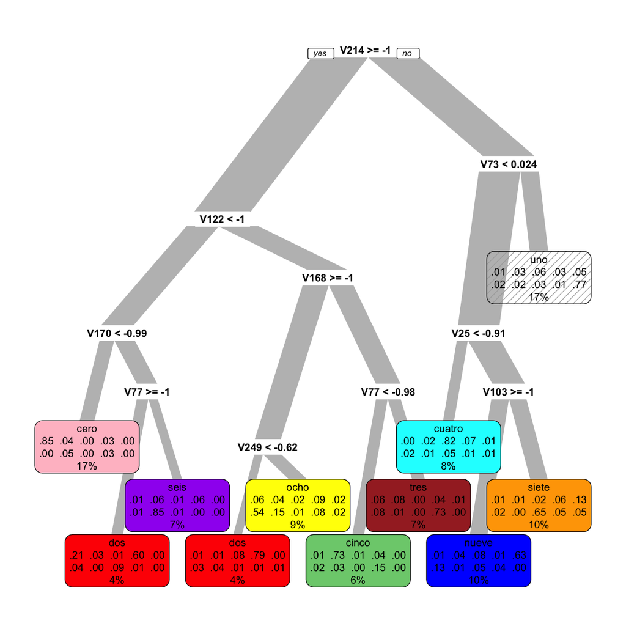

```r
modelo <- train.rpart(Numero~.,data = taprendizaje,minsplit=5, maxdepth = 4)
prp(modelo,extra=104,
    branch.type=2,
    box.col=c("pink",
              "palegreen3",
              "cyan",
              "red",
              "blue",
              "yellow",
              "purple",
              "orange",
              "brown")[modelo$frame$yval])
```

## 3.

Compare los resultados con los obtenidos en las tareas anteriores.

### Árboles de Decisión

```r
prediccion <- predict(modelo, ttesting,type = "class")
MC.AD <- confusion.matrix(ttesting,prediccion)
```

### KNN

```r
#rectangular
modelo.rectangular <-train.knn(Numero~.,data=taprendizaje, kernel = "rectangular")
prediccion.rectangular <- predict(modelo.rectangular, ttesting, type = "class")

MC.rectangular <- confusion.matrix(ttesting, prediccion.rectangular)

#triangular
modelo.triangular <- train.knn(Numero~., data = taprendizaje, kernel = "triangular")

prediccion.triangular <- predict(modelo.triangular, ttesting, type = "class")

MC.triangular<- confusion.matrix(ttesting ,prediccion.triangular)

#epanechnikov
modelo.epanechnikov <- train.knn(Numero~., data = taprendizaje, kernel = "epanechnikov")

prediccion.epanechnikov <- predict(modelo.epanechnikov, ttesting, type = "class")

MC.epanechnikov<- confusion.matrix(ttesting ,prediccion.epanechnikov)

#biweight
modelo.biweight <- train.knn(Numero~., data = taprendizaje, kernel = "biweight")

prediccion.biweight <- predict(modelo.biweight, ttesting, type = "class")

MC.biweight<- confusion.matrix(ttesting ,prediccion.biweight)

#triweight
modelo.triweight <- train.knn(Numero~., data = taprendizaje, kernel = "triweight")

prediccion.triweight <- predict(modelo.triweight, ttesting, type = "class")

MC.triweight<- confusion.matrix(ttesting ,prediccion.triweight)

#cos
modelo.cos <- train.knn(Numero~., data = taprendizaje, kernel = "cos")

prediccion.cos <- predict(modelo.cos, ttesting, type = "class")

MC.cos<- confusion.matrix(ttesting,prediccion.cos)

#inv
modelo.inv <- train.knn(Numero~., data = taprendizaje, kernel = "inv")

prediccion.inv <- predict(modelo.inv, ttesting, type = "class")

MC.inv<- confusion.matrix(ttesting ,prediccion.inv)

#optimal
modelo.optimal <- train.knn(Numero~., data = taprendizaje, kernel = "optimal")

prediccion.optimal <- predict(modelo.optimal, ttesting, type = "class")

MC.optimal<- confusion.matrix(ttesting ,prediccion.optimal)
```

### SVM

```r
#linear
modelo.linear <- train.svm(Numero~., data = taprendizaje, kernel = "linear")
prediccion.linear <- predict(modelo.linear, ttesting , type = "class")
MC.Linear <- confusion.matrix(ttesting, prediccion.linear)

#polynomial
modelo.polynomial <- train.svm(Numero~., data = taprendizaje, kernel = "polynomial")
prediccion.polynomial <- predict(modelo.polynomial, ttesting , type = "class")
MC.polynomial <- confusion.matrix(ttesting, prediccion.polynomial)

#radial
modelo.radial <- train.svm(Numero~., data = taprendizaje, kernel = "radial")
prediccion.radial <- predict(modelo.radial, ttesting , type = "class")
MC.radial <- confusion.matrix(ttesting, prediccion.radial)

#sigmoid
modelo.sigmoid <- train.svm(Numero~., data = taprendizaje, kernel = "sigmoid")
prediccion.sigmoid <- predict(modelo.sigmoid, ttesting , type = "class")
MC.sigmoid <- confusion.matrix(ttesting, prediccion.sigmoid)
```

### Tabla Comparativa

```r
library(dplyr)


indices1 <- indices.general(MC.AD)
indices2 <- indices.general(MC.rectangular)
indices3 <- indices.general(MC.triangular)
indices4 <- indices.general(MC.epanechnikov)
indices5 <- indices.general(MC.biweight)
indices6 <- indices.general(MC.triweight)
indices7 <- indices.general(MC.cos)
indices8 <- indices.general(MC.inv)

indices9 <- indices.general(MC.Linear)
indices10 <- indices.general(MC.polynomial)
indices11 <- indices.general(MC.radial)
indices12 <- indices.general(MC.sigmoid)



indices1$`Precisión por categoría`<-sprintf("%f,%f", indices1$`Precisión por categoría`[1], indices1$`Precisión por categoría`[2])

indices2$`Precisión por categoría`<-sprintf("%f,%f", indices2$`Precisión por categoría`[1], indices2$`Precisión por categoría`[2])

indices3$`Precisión por categoría`<-sprintf("%f,%f", indices3$`Precisión por categoría`[1], indices3$`Precisión por categoría`[2])

indices4$`Precisión por categoría`<-sprintf("%f,%f", indices4$`Precisión por categoría`[1], indices4$`Precisión por categoría`[2])

indices5$`Precisión por categoría`<-sprintf("%f,%f", indices5$`Precisión por categoría`[1], indices5$`Precisión por categoría`[2])

indices6$`Precisión por categoría`<-sprintf("%f,%f", indices6$`Precisión por categoría`[1], indices6$`Precisión por categoría`[2])

indices7$`Precisión por categoría`<-sprintf("%f,%f", indices7$`Precisión por categoría`[1], indices7$`Precisión por categoría`[2])

indices8$`Precisión por categoría`<-sprintf("%f,%f", indices8$`Precisión por categoría`[1], indices8$`Precisión por categoría`[2])

indices9$`Precisión por categoría`<-sprintf("%f,%f", indices9$`Precisión por categoría`[1], indices9$`Precisión por categoría`[2])

indices10$`Precisión por categoría`<-sprintf("%f,%f", indices10$`Precisión por categoría`[1], indices10$`Precisión por categoría`[2])

indices11$`Precisión por categoría`<-sprintf("%f,%f", indices11$`Precisión por categoría`[1], indices11$`Precisión por categoría`[2])

indices12$`Precisión por categoría`<-sprintf("%f,%f", indices12$`Precisión por categoría`[1], indices12$`Precisión por categoría`[2])


tablaComparativa <-  rbind(as.data.frame(indices1),as.data.frame(indices2),as.data.frame(indices3),as.data.frame(indices4),as.data.frame(indices5),as.data.frame(indices6),as.data.frame(indices7),as.data.frame(indices8),as.data.frame(indices9),as.data.frame(indices10),as.data.frame(indices11),as.data.frame(indices12))

rownames(tablaComparativa) <- c("arboles decision","rectangular", "triangular", "epanechnikov", "biweight", "triweight", "cos", "inv","linear","polynomial","radial", "sigmoid")

tablaComparativa
```

```
                 Precisión.Global Error.Global Precisión.por.categoría
arboles decision        0.7295699   0.27043011       0.860465,0.551471
rectangular             0.9602151   0.03978495       0.996678,0.889706
triangular              0.9591398   0.04086022       0.996678,0.897059
epanechnikov            0.9591398   0.04086022       0.996678,0.897059
biweight                0.9623656   0.03763441       0.996678,0.897059
triweight               0.9634409   0.03655914       0.996678,0.897059
cos                     0.9591398   0.04086022       0.996678,0.897059
inv                     0.9586022   0.04139785       0.996678,0.889706
linear                  0.9446237   0.05537634       0.980066,0.845588
polynomial              0.9666667   0.03333333       0.993355,0.948529
                 Falsos.positivos Falsos.negativos Asertividad.Positiva
arboles decision      0.000000000      0.132352941            0.7425743
rectangular           0.000000000      0.036764706            0.9603175
triangular            0.000000000      0.036764706            0.9682540
epanechnikov          0.000000000      0.029411765            0.9682540
biweight              0.000000000      0.029411765            0.9682540
triweight             0.000000000      0.029411765            0.9606299
cos                   0.000000000      0.036764706            0.9682540
inv                   0.000000000      0.022058824            0.9758065
linear                0.006644518      0.029411765            0.9583333
polynomial            0.000000000      0.007352941            0.9626866
                 Asertvidad.Negativa
arboles decision           0.8633333
rectangular                0.9404389
triangular                 0.9375000
epanechnikov               0.9404389
biweight                   0.9433962
triweight                  0.9463722
cos                        0.9375000
inv                        0.9433962
linear                     0.9485531
polynomial                 0.9803279
 [ reached 'max' / getOption("max.print") -- omitted 2 rows ]
```

```r
#Mejor Método basado en su Precisión Global
tablaComparativa%>%
  filter(Precisión.Global ==  max(Precisión.Global))
```

```
           Precisión.Global Error.Global Precisión.por.categoría
polynomial        0.9666667   0.03333333       0.993355,0.948529
radial            0.9666667   0.03333333       0.996678,0.933824
           Falsos.positivos Falsos.negativos Asertividad.Positiva
polynomial                0      0.007352941            0.9626866
radial                    0      0.022058824            0.9548872
           Asertvidad.Negativa
polynomial           0.9803279
radial               0.9677419
```

# Pregunta 4

[10 puntos] [no usar rpart ni traineR] Considere los datos de entrenamiento que se muestran en la siguiente Tabla para un problema de clasificación binaria.

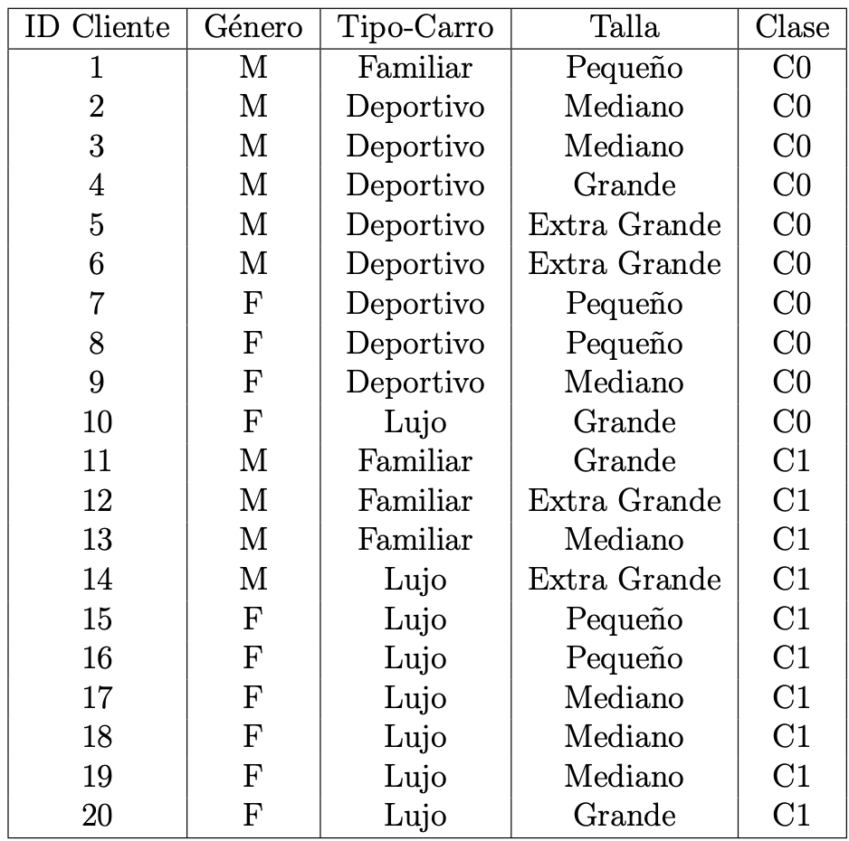

```r
knitr::include_graphics("Captura de Pantalla 2020-10-13 a la(s) 10.24.06.png")
```

```r
#Datos en dataframe
ID <- 1:20
Genero <- c("M","M","M","M","M","M","F","F","F","F","M","M","M","M","F","F","F","F","F","F")
TipoCarro <- c("Familiar", "Deportivo", "Deportivo","Deportivo", "Deportivo","Deportivo", "Deportivo","Deportivo", "Deportivo","Lujo", "Familiar","Familiar","Familiar","Lujo","Lujo","Lujo","Lujo","Lujo","Lujo","Lujo")
Talla <- c("Pequeno", "Mediano","Mediano","Grande","Extra Grande", "Extra Grande", "Pequeno","Pequeno","Mediano","Grande","Grande","Extra Grande","Mediano","Extra Grande","Pequeno","Pequeno","Mediano","Mediano","Mediano", "Grande")
Clase <- c("C0","C0","C0","C0","C0","C0","C0","C0","C0","C0","C1","C1","C1","C1","C1","C1","C1","C1","C1","C1")

Datos <- data.frame(ID,Genero,TipoCarro,Talla,Clase)
Datos
```

```
   ID Genero TipoCarro        Talla Clase
1   1      M  Familiar      Pequeno    C0
2   2      M Deportivo      Mediano    C0
3   3      M Deportivo      Mediano    C0
4   4      M Deportivo       Grande    C0
5   5      M Deportivo Extra Grande    C0
6   6      M Deportivo Extra Grande    C0
7   7      F Deportivo      Pequeno    C0
8   8      F Deportivo      Pequeno    C0
9   9      F Deportivo      Mediano    C0
10 10      F      Lujo       Grande    C0
11 11      M  Familiar       Grande    C1
12 12      M  Familiar Extra Grande    C1
13 13      M  Familiar      Mediano    C1
14 14      M      Lujo Extra Grande    C1
15 15      F      Lujo      Pequeno    C1
 [ reached 'max' / getOption("max.print") -- omitted 5 rows ]
```

## 1.

Calcule el índice de Gini para la tabla completa.

```r
indiceGini <- 1- (10/20)^2 - (10/20)^2
indiceGini
```

```
[1] 0.5
```

## 2.

Calcule el índice de Gini para la variable Género.

```r
Datos%>%
  group_by(Clase)%>%
  count(Genero)
```

```
# A tibble: 4 x 3
# Groups:   Clase [2]
  Clase Genero     n
  <chr> <chr>  <int>
1 C0    F          4
2 C0    M          6
3 C1    F          6
4 C1    M          4
```

```r
giniFem <- 1- (4/10)^2 - (6/10)^2
giniFem
```

```
[1] 0.48
```

```r
giniMasc <- 1- (4/10)^2 - (6/10)^2
giniMasc
```

```
[1] 0.48
```

```r
giniSlipGenero <- (10/20)*giniFem + (10/20)*giniMasc
giniSlipGenero
```

```
[1] 0.48
```

## 3.

Calcule el índice de Gini para la variable Tipo-Carro.

```r
Datos%>%
  group_by(Clase)%>%
  count(TipoCarro)
```

```
# A tibble: 5 x 3
# Groups:   Clase [2]
  Clase TipoCarro     n
  <chr> <chr>     <int>
1 C0    Deportivo     8
2 C0    Familiar      1
3 C0    Lujo          1
4 C1    Familiar      3
5 C1    Lujo          7
```

```r
giniDeportivo <- 1-(8/8)^2-(0/8)^2
giniDeportivo
```

```
[1] 0
```

```r
giniFamiliar <- 1 - (1/4)^2 - (3/4)^2
giniFamiliar
```

```
[1] 0.375
```

```r
giniLujoDeport <- 1 - (9/16)^2 - (7/16)^2
giniLujoDeport
```

```
[1] 0.4921875
```

```r
#Se usa la combinación Lujo/deporti y Familiar
giniSlipTipoCarro <- (4/20)*giniFamiliar + (16/20)*giniLujoDeport
giniSlipTipoCarro
```

```
[1] 0.46875
```

## 4.

Calcule el índice de Gini para la variable Talla.

```r
Datos%>%
  group_by(Clase)%>%
  count(Talla)
```

```
# A tibble: 8 x 3
# Groups:   Clase [2]
  Clase Talla            n
  <chr> <chr>        <int>
1 C0    Extra Grande     2
2 C0    Grande           2
3 C0    Mediano          3
4 C0    Pequeno          3
5 C1    Extra Grande     2
6 C1    Grande           2
7 C1    Mediano          4
8 C1    Pequeno          2
```

```r
giniExtraGrande <- 1- (2/4)^2 - (2/4)^2
giniExtraGrande
```

```
[1] 0.5
```

```r
giniGrande <- 1- ((2+2)/(4+4))^2 - ((2+2)/(4+4))^2
giniGrande
```

```
[1] 0.5
```

```r
giniMediano <- 1- (3/7)^2 - (4/7)^2
giniMediano
```

```
[1] 0.4897959
```

```r
giniPequeno <- 1 - ((3+3)/(5+7))^2 - ((2+4)/(5+7))^2
giniPequeno
```

```
[1] 0.5
```

```r
# Se usa la combinación ExtraGra/Grande y Mediano/Pequeñ
giniSlipTalla <-  ((4+4)/20)*giniGrande  + ((5+7)/20)*giniPequeno
giniSlipTalla
```

```
[1] 0.5
```

## 5.

¿Cuál variable es mejor, Género, Tipo-Carro o Talla?

```r
Ginis <- c(giniSlipGenero,giniSlipTipoCarro,giniSlipTalla)

names(Ginis) <- c("Genero","Tipo Carro", "Talla")

Ginis[Ginis == min(Ginis)]
```

```
Tipo Carro
   0.46875
```

## 6.

Explique por qué el ID Cliente no se debe usar como variable aunque tenga el Gini más bajo.

Por que no es una variable que aporte información valiosa, también podría decirse que no es ni siquiera una variable sino más bien identificadores.